# GLDM3001: Module 8 - Exercises

YOUR_NAME

2022-11-16

## Using unsupervised learning for vehicle clustering

> Store the data file “2016 FEGuide.xlsx” in a subfolder by the name ‘data’ in your working directory.

**Note:** You may need to adjust the code below to specify the “2016 FEGuide.xlsx” file location if you opt out to store the data file in different location.

#### Read the data into data frame by running the code

```r
# load the readxl package to read the xlsx file in R
library(readxl)

# set the working directory to the current one, where you downloaded the file
work_dir <- getwd()
setwd(work_dir)

filename <- fs::dir_ls("16data", regexp = "public\\.xlsx") %>% head(1)

# use read_excel function to read the file by creating the full path to it, using paste0 function.


cars <- read_excel(filename) %>%
  janitor::clean_names() %>%
  dplyr::select(
    make = mfr_name,
    model = carline,
    displacement = eng_displ,
    number_cyl,
    number_gears,
    city_mpg = city_fe_guide_conventional_fuel,
    hwy_mpg = hwy_fe_guide_conventional_fuel
  ) %>%
  distinct(model, .keep_all = TRUE) %>%
  filter(make == "General Motors")
# have a look at the data
glimpse(cars)
```

```
Rows: 79
Columns: 7
$ make         <chr> "General Motors", "General Motors", "General Motors", "Gene…
$ model        <chr> "CORVETTE", "CASCADA", "SPARK", "VERANO", "ATS", "ATS AWD",…
$ displacement <dbl> 6.2, 1.6, 1.4, 2.0, 2.0, 2.0, 3.6, 2.0, 1.4, 1.4, 1.4, 1.4,…
$ number_cyl   <dbl> 8, 4, 4, 4, 4, 4, 6, 4, 4, 4, 4, 4, 4, 6, 4, 4, 4, 4, 8, 4,…
$ number_gears <dbl> 8, 6, 1, 6, 8, 8, 8, 8, 6, 6, 6, 6, 6, 6, 6, 6, 8, 8, 8, 6,…
$ city_mpg     <dbl> 13, 20, 31, 21, 22, 22, 16, 22, 30, 30, 27, 25, 25, 17, 21,…
$ hwy_mpg      <dbl> 23, 27, 41, 30, 31, 30, 24, 31, 42, 40, 37, 33, 36, 26, 30,…
```

**Exercise 1:** Modify the code above or write new code to choose the car maker `General Motors`. How many records (rows) are in the data?

```r
dim(cars)
```

```
[1] 79  7
```

**Exercise 2:** Run the code below to see the first vehicle in `cars`. What is the model?

```r
cars[1, ]
```

| make | model | displacement | number_cyl | number_gears | city_mpg | hwy_mpg |
| --- | --- | --- | --- | --- | --- | --- |
| General Motors | CORVETTE | 6.2 | 8 | 8 | 13 | 23 |

```r
NA
```

**Exercise 3:** Write code to find out how many **different** models of `General Motors` vehicles are in the `cars` data frame.

```r
length(models_GM)
```

```
[1] 79
```

**Exercise 4:** The code below uses `dist()` function to provide the distance from each individual car to every other car. Add code to obtain the class of the `car_diffs` and the `car_mat` objects.

```r
car_diffs <- cars %>%
  column_to_rownames(var = "model") %>% #  convert the second column from cars (model) to row names (from tibble package)
  dist()

#erase
class(car_diffs)
```

```
[1] "dist"
```

```r
# convert the
car_mat <- car_diffs %>%
  as.matrix()

car_mat[1:6, 1:6] %>% # try 10 instead of 6
  round(digits = 2)
```

```
         CORVETTE CASCADA SPARK VERANO   ATS ATS AWD
CORVETTE     0.00   11.29 29.72  13.44 14.64   14.01
CASCADA     11.29    0.00 20.26   3.49  5.38    4.54
SPARK       29.72   20.26  0.00  17.19 16.63   17.37
VERANO      13.44    3.49 17.19   0.00  2.68    2.45
ATS         14.64    5.38 16.63   2.68  0.00    1.10
ATS AWD     14.01    4.54 17.37   2.45  1.10    0.00
```

```r
#erase
class(car_mat)
```

```
[1] "matrix" "array"
```

**Exercise 5:** The code below produces the `phylo` tree. Adjust the `cex` parameter in `plot()` to improve readability of the labels as much as possible.

[figure not shown]

```r
library(ape)
car_diffs %>%
  hclust() %>%
  as.phylo() %>%
  plot(cex = 1, label.offset = .5) # adjust the cex to better visualize
```

**Exercise 6:** The code below choose 4,000 biggest cities, from the data `world_cities` in the world and their longitudes and latitudes to a data frame called `big_cities`. Add code to find out how many cities were left out of the total available in the `world_cities` data.

```r
big_cities <- world_cities %>%
  arrange(desc(population)) %>%
  head(4000) %>%
  dplyr::select(longitude, latitude)
glimpse(big_cities)
```

```
Rows: 4,000
Columns: 2
$ longitude <dbl> 121.45806, 28.94966, -58.37723, 72.88261, -99.12766, 116.39723…
$ latitude  <dbl> 31.22222, 41.01384, -34.61315, 19.07283, 19.42847, 39.90750, 2…
```

```r
dim(world_cities)
```

```
[1] 4428    9
```

**Exercise 7:** Run the `k-means` clustering algorithm code to separate these `4,000` points—each of which is located in a two-dimensional plane—into `k=6` clusters based on their locations alone. Re-run the code for `centers = 3,4,5,7,8`. Which cluster appear to persist based on coloration?

```r
set.seed(15)
# install the package first if not installed
#install.packages("mclust")
library(mclust)

# form 6 cluster iteratively
city_clusts <- big_cities %>%
  kmeans(centers = 6, nstart =10) %>%
  fitted("classes") %>%
  as.character()

# form 6 cluster iteratively, by forming initially 10 random sets
km <- kmeans(big_cities, centers = 6, nstart = 10)

# inspect the structure of the kmeans output cluster object
str(km)
```

[output not shown]

```r
# access two important features of cluster, their size and centers
km$size
```

```
[1] 988 554 726 984 356 392
```

```r
km$centers
```

[output not shown]

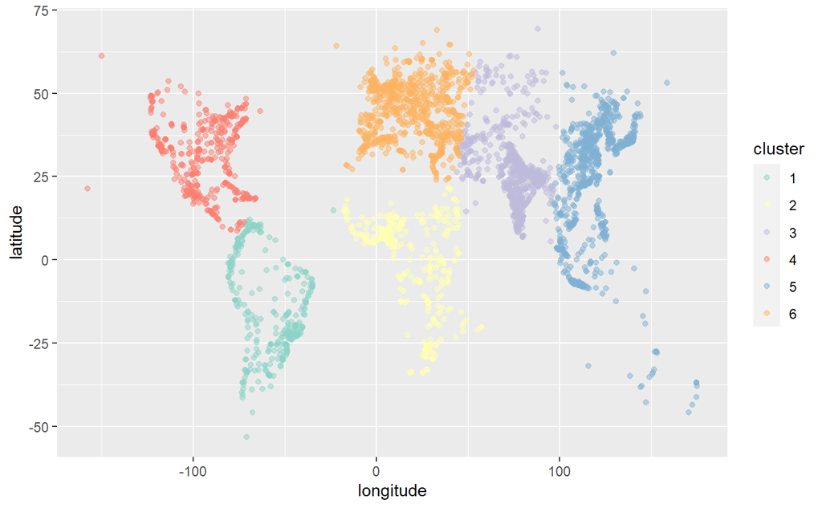

```r
# add a variable to record the cluster to which a point belongs to
big_cities <- big_cities %>%
  mutate(cluster = city_clusts)

# graph the clusters, using the cluster variable to pick the color
big_cities %>%
  ggplot(aes(x = longitude, y = latitude)) +
  geom_point(aes(color = cluster), alpha = 0.5)  +
  scale_color_brewer(palette = "Set3")
```

**Exercise 8:** The code below uses the **EPSG:4326** (WGS84) CRS and runs `K-means` algorithm on the `big_cities` data and visualizes the results.

```r
library(rgdal)

# assign the big_cities data.frame to a working data.frame object df
df <- big_cities

# create spatial object from d
coordinates(df) <- 1:2

# Set WGS 84 (EPSG:4326) standard for projecting longitude latitude coordinates
proj4string(df) <- CRS("+init=epsg:4326")

# coordinate reference system using the EPSG:4326 standard
CRS.new <- CRS("+init=epsg:4326")

# the d object in the new CRS, you may print out few records to see how it looks in the new CRS
df.new <- spTransform(df, CRS.new)

# just for information review the
proj4string(df.new) %>% strwrap()
```

```
[1] "+proj=longlat +datum=WGS84 +no_defs"
```

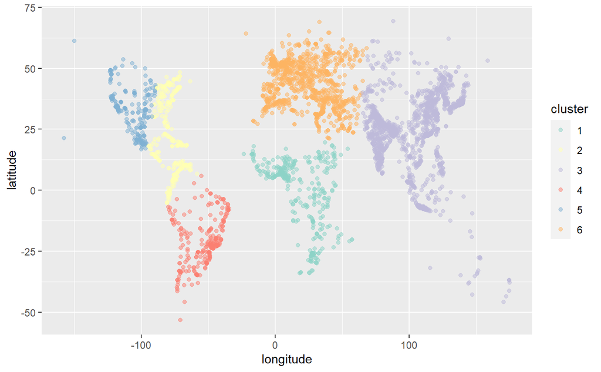

```r
# form 6 cluster iteratively
city_clusts <- as.data.frame(df.new) %>%
kmeans(centers = 6) %>% fitted("classes") %>% as.character()

# add a variable for the newly formed clusters
df.new <- as.data.frame(df.new) %>% mutate(cluster = city_clusts)

# graph the clusters, using the cluster variable to pick the color
df.new %>% ggplot(aes(x = longitude, y = latitude)) +
geom_point(aes(color = cluster), alpha = 0.5) +
scale_color_brewer(palette = "Set3")
```

```r
NA
NA
```

**Exercise 9:** Modify the code from **Exercise 8** to produce run runs `K-means` algorithm on the `big_cities` data and visualizes the results in **EPSG:4269** (NAD83) CRS.

```r
# Set NAD83 (EPSG:4269) standard for projecting longitude latitude coordinates
proj4string(df) <- CRS("+init=epsg:4269")
# coordinate reference system using the EPSG:4326 standard
CRS.new <- CRS("+init=epsg:4269")

# the d object in the new CRS, you may print out few records to see how it looks in the new CRS
df.new <- spTransform(df, CRS.new)

# just for information review the
proj4string(df.new) %>% strwrap()
```

```
[1] "+proj=longlat +datum=NAD83 +no_defs"
```

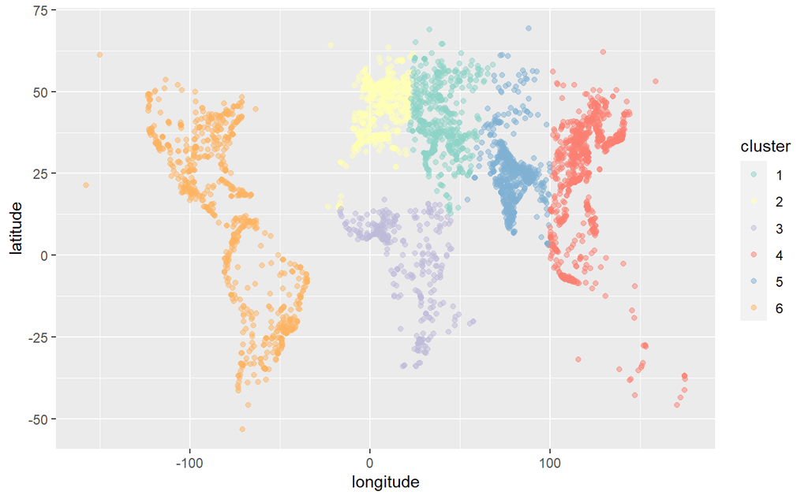

```r
# form 6 cluster iteratively
city_clusts <- as.data.frame(df.new) %>%
kmeans(centers = 6) %>% fitted("classes") %>% as.character()

# add a variable for the newly formed clusters
df.new <- as.data.frame(df.new) %>% mutate(cluster = city_clusts)

# graph the clusters, using the cluster variable to pick the color
df.new %>% ggplot(aes(x = longitude, y = latitude)) +
geom_point(aes(color = cluster), alpha = 0.5) +
scale_color_brewer(palette = "Set3")
```

**Exercise 10:** Compare how the cluster differ across the different choice of CRS.